# Differential_expression_Amix

Fabian C. Salgado-Roa

2026-01-12

# 1 Load packages and inputs

## 1.1 R packages

```r
library(tidyverse)
library(DESeq2)
library(tximport)
library(goseq)
library(EnhancedVolcano)
library(gridExtra)
```

## 1.2 Set working directory

```r
#home
#setwd("C:/Users/Fabian C. Salgado/Dropbox/PhD_FabianSalgado/research_proposal/aim4/analyses/expression")
#laptop
setwd("C:/Users/facas/Dropbox/PhD_FabianSalgado/research_proposal/aim4/analyses/expression")
```

## 1.3 Account for overrepresentation

Create a tx2gene file that later will be use for over representation analyses

```r
entap<-read.table("../annotation_m1_m3_a/final_results/entap_results.tsv",header=TRUE, sep="\t", quote="", comment.char="")

entap_ann <- entap[!is.na(entap$Description), ] # remove sequences with no annotation

entap_ann <- entap_ann %>%
  mutate(gene = str_remove(.[[1]], "_i\\d+$"))

# Summarize by gene
final_tbl <- entap_ann %>%
  group_by(gene) %>%
  summarise(
    isoforms = n(),                               # number of isoforms
    annotation = paste(unique(Description), collapse = "; "),  # unique annotations
    .groups = "drop"
  )

# Count number of annotations per gene
final_tbl$num_anno <- sapply(strsplit(final_tbl$annotation, ";"), length)

# Check number of "genes" with a single annotation
table(final_tbl$num_anno)
```

```
##
##     1     2     3     4     5     6     7     8
## 14857  3417  1042   309    95    35     9     2
```

```r
# check the number of "genes" that where having redundant isoforms
final_tbl[final_tbl$isoforms > 1 & final_tbl$num_anno == 1, ] %>% nrow()
```

```
## [1] 3329
```

```r
df_ann <- entap_ann %>%
  mutate(
    transcript = .[[1]],
    base_gene = str_remove(transcript, "_i\\d+$")
  )

# Step 2: For each gene, check whether multiple annotations exist
rosetta_stone <- df_ann %>%
  group_by(base_gene) %>%
  mutate(
    anno_unique = n_distinct(Subject.Sequence),
    gene = ifelse(anno_unique == 1, base_gene, transcript)
  ) %>%
  ungroup() %>%
  select(transcript, gene)

rosetta_stone
```

| transcript | gene |
| --- | --- |
| TRINITY_DN208258_c0_g1_i1 | TRINITY_DN208258_c0_g1 |
| TRINITY_DN226351_c0_g1_i1 | TRINITY_DN226351_c0_g1 |
| TRINITY_DN226380_c0_g1_i2 | TRINITY_DN226380_c0_g1 |
| TRINITY_DN226309_c0_g1_i1 | TRINITY_DN226309_c0_g1 |
| TRINITY_DN219639_c0_g1_i1 | TRINITY_DN219639_c0_g1 |
| TRINITY_DN215094_c0_g1_i1 | TRINITY_DN215094_c0_g1 |
| TRINITY_DN209300_c0_g1_i1 | TRINITY_DN209300_c0_g1 |
| TRINITY_DN229321_c0_g1_i1 | TRINITY_DN229321_c0_g1 |
| TRINITY_DN226239_c0_g1_i1 | TRINITY_DN226239_c0_g1 |
| TRINITY_DN220883_c0_g1_i1 | TRINITY_DN220883_c0_g1 |

[output cut: 9990 more lines]

## 1.4 Annotation file

We will read a table containing our gene annotations from EnTAP

```r
ann <- read.table("../annotation_m1_m3_a/final_results/entap_results.tsv",header=TRUE, sep="\t",quote="", comment.char="")
```

match GOmap file

```r
GOmap <- read.table("../annotation_m1_m3_a/final_results/annotated_gene_ontology_terms.tsv",sep="\t",quote="",comment.char="",header=TRUE) %>%
  mutate(gene_id=str_remove(query_sequence, ".p[0-9]+$"))

shared_transcripts <- df_ann %>%
  group_by(Subject.Sequence) %>%
  filter(n() > 1) %>%
  pull(transcript)

pos<-which(GOmap$query_sequence %in% shared_transcripts)

GOmap$gene_id[pos] <- GOmap$gene_id[pos] %>% str_remove("_i\\d+$")
```

## 1.5 Predicted proteins

Read in information about the predicted proteins from transdecoder

```r
bed <- read.table("../annotation_m1_m3_a/nonredundant_M1_M3_A.fasta.transdecoder.bed", sep="\t", quote="", comment.char="", skip=1) %>%
  mutate(
    pepID=str_extract(V4, "(?<=ID=)[^;]+"),
    score=str_extract(V4, "(?<=score=)[^,]+"))
```

Get transcript length form this file

```r
len <- read_delim("../assembly_M1_M3_A/trans_len.txt",col_names = FALSE, delim = " ")
names(len)<-c("transcript","length")
```

Annotations were created for the predicted proteins using TransDecoder. This implies:

*Some transcripts might be associated with more than one predicted protein (most of which are likely artifacts).

*Transcript names now have .pX added to them.

We will address this further below:

```r
bed <- select(bed, V1,pepID,score) %>%
  group_by(V1) %>%
  summarize(Transcript.ID=V1[which.max(score)],Peptide.ID=pepID[which.max(score)])
```

Merge transcript/peptide IDs into annotation

```r
tab <- merge(select(bed,Peptide.ID,Transcript.ID),ann,by.x="Transcript.ID",by.y="Query.Sequence")
```

## 1.6 Import raw count data from Salmon

```r
output_dir<-"salmon_m1_m3_a/"

list_dir <- list.files(output_dir, pattern = "quant.sf$", recursive = TRUE, full.names = TRUE)

#sample information
sample_file<-read.table("all_reads.txt")

sample_file<-sample_file[order(sample_file$V2),] #to match the directory order

sample_names<-sample_file$V3

stage<-sample_file$V1 %>% gsub(pattern="\\_\\w+$", replacement="")

colour<-sample_file$V1 %>% gsub(pattern="^\\w+\\_", replacement="")

egg<-gsub(pattern ="\\_3\\w+|\\_A\\w+|\\_1\\w+" ,replacement = "" ,x=sample_names)

coldata<-data.frame(sample_names,stage,colour,egg) # All the sample data in a single dataframe

#import all the result with tximport
txi <- tximport(list_dir, type = "salmon",txOut=TRUE,ignoreTxVersion = TRUE)
```

```
## reading in files with read_tsv
```

```
## 1 2 3 4 5 6 7 8 9 10 11 12 13 14 15 16 17 18 19 20 21 22 23 24 25 26 27 28 29 30 31 32 33 34 35 36 37
```

Merge the counts data frame with the annotations

We will modify the EnTAP results to deal with transcripts and lineage contamination

```r
tab <- mutate(
  tab,
  Contaminant = replace_na(Contaminant, "Unknown"),
  Taxonomic.Lineage = replace_na(Taxonomic.Lineage, "Unknown"),
  Prevalence = rowSums(tab[,1:37]>0)
  )
```

# 2 Annotation quality

Let´s summarize total expression per sample by annotation status

## 2.1 Annotation status per samples

Visualize the annotation status of each sample (No database hit, annotated, uninformative hit)

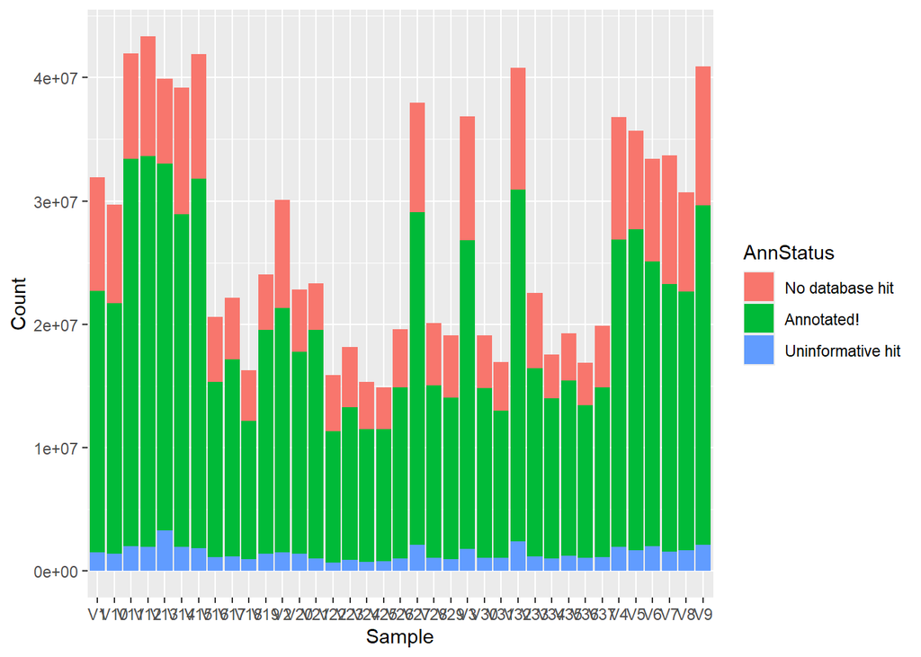

```r
ggplot(byann,aes(fill=AnnStatus,y=Count,x=Sample)) +
  geom_bar(position="stack",stat="identity")
```

## Summarize expression per sample by contaminant status

Summarize the results in a single data frame

```r
bycontam <- group_by(tab,Contaminant) %>%
  summarize(across(V1:V37,sum)) %>% # get the summaries
  pivot_longer(!Contaminant,names_to="Sample",values_to="Count") %>%
  mutate(Contaminant = fct_relevel(Contaminant,c("Unknown","Yes","No"))) %>%
  as.data.frame()
```

Visualise the results

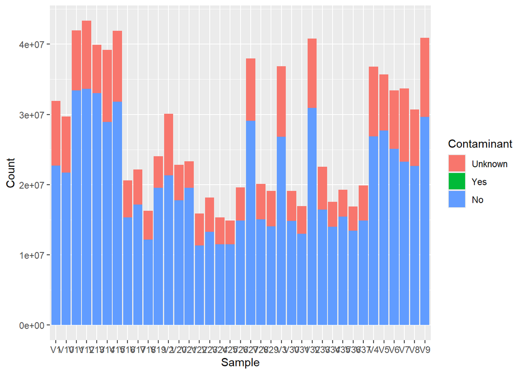

```r
ggplot(bycontam,aes(fill=Contaminant,y=Count,x=Sample)) +
  geom_bar(position="stack",stat="identity")
```

**All the samples have low levels of contamination**

## 2.2 Summarize total expression per sample by taxonomy

Here we will explore how accurate our annotation was. We expect to find that most of our transcripts correspond to arachnid proteins.

Using the column *Taxonomic.Lineage*, let’s get a fast summary

```r
str_split(tab$Taxonomic.Lineage,";") %>% unlist() %>% table() %>% sort() %>% tail(n=50) %>% t()
```

```
##       .
##        vertebrata chordata deuterostomia trichonephila clavipes
##   [1,]        453      464           527                    547
##       .
##        trichonephila inaurata trichonephila inaurata madagascariensis
##   [1,]                    680                                     680
##       .
##        parasteatoda parasteatoda tepidariorum theridiidae endopterygota
##   [1,]          849                       849         852           901
##       .
##        trichonephila clavata stegodyphus dumicola nephila pilipes nephila
##   [1,]                   923                 1032            1132    1136
##       .
##        neoptera dicondylia insecta pterygota hexapoda eresidae eresoidea
##   [1,]     1309       1341    1341      1341     1349     1389      1389
##       .
##        stegodyphus pancrustacea mandibulata trichonephila nephilidae
##   [1,]        1389         1533        1539          2150       3286
##       .
##        araneus ventricosus araneus argiope bruennichi argiope araneidae
##   [1,]                6965    6976              18803   18815     25792
##       .
##        araneoidea orbiculariae entelegynae araneomorphae araneae arachnida
##   [1,]      29930        30305       31704         31709   31717     32346
##       .
##        chelicerata arthropoda panarthropoda ecdysozoa protostomia bilateria
##   [1,]       32515      34054         34056     34159       34507     35034
##       .
##        eumetazoa metazoa opisthokonta eukaryota cellular organisms   root
##   [1,]     35114   35123        35139     35192              35205  35286
##       .
##        Unknown
##   [1,]  300416
```

```r
str_extract(tab$Taxonomic.Lineage, "[^;]+(?=;root)") %>% table()
```

```
## .
## cellular organisms            viruses
##              35205                 81
```

```r
str_extract(tab$Taxonomic.Lineage, "[^;]+(?=;cellular organisms)") %>% table()
```

```
## .
##   archaea  bacteria eukaryota
##         3        10     35192
```

```r
str_extract(tab$Taxonomic.Lineage, "^[^;]+") %>% table() %>% sort() %>% tail(n=50)  %>% t()
```

```
##       .
##        hydra vulgaris lasius niger patella vulgata penaeus vannamei
##   [1,]             14           14              14               14
##       .
##        vespa mandarinia bombyx mori bos taurus orbicella faveolata ladona fulva
##   [1,]               14          16         16                  16           17
##       .
##        cherax quadricarinatus graphocephala atropunctata
##   [1,]                     18                         18
##       .
##        mytilus galloprovincialis dermacentor silvarum lygus hesperus
##   [1,]                        18                   19             19
##       .
##        poeciliopsis prolifica dreissena polymorpha harpegnathos saltator
##   [1,]                     19                   21                    21
##       .
##        ixodes ricinus lingula anatina ruditapes philippinarum
##   [1,]             21              21                      22
##       .
##        haemaphysalis longicornis homalodisca liturata cuerna arida
##   [1,]                        24                   24           25
##       .
##        lytechinus pictus ornithodoros moubata saccostrea cucullata
##   [1,]                25                   25                   25
##       .
##        homarus americanus ornithodoros erraticus diaphorina citri
##   [1,]                 29                     29               30
##       .
##        photinus pyralis drosophila melanogaster rhipicephalus microplus
##   [1,]               35                      39                      40
##       .
##        ixodes scapularis mus musculus cryptotermes secundus homo sapiens
##   [1,]                45           48                    49           55
##       .
##        rhipicephalus sanguineus limulus polyphemus centruroides sculpturatus
##   [1,]                       58                164                       206
##       .
##        stegodyphus mimosarum uloborus diversus trichonephila clavipes
##   [1,]                   357               375                    547
##       .
##        trichonephila inaurata madagascariensis parasteatoda tepidariorum
##   [1,]                                     680                       849
##       .
##        trichonephila clavata stegodyphus dumicola nephila pilipes
##   [1,]                   923                 1032            1132
##       .
##        araneus ventricosus argiope bruennichi Unknown
##   [1,]                6965              18803  300416
```

According to this summary, it seems that we are on the right path. Let’s explore the results per sample, in case there are some samples that we need to remove form further analyses.

For this I will use some categorize of interest

```r
tab <- mutate(tab,
              TaxGroup=case_when(
                str_detect(Taxonomic.Lineage, "archaea") ~ "archaea",
                str_detect(Taxonomic.Lineage, "bacteria") ~ "bacteria",
                str_detect(Taxonomic.Lineage, "fungi") ~ "fungi",
                str_detect(Taxonomic.Lineage, "mammalia") ~ "mamifero",
                str_detect(Taxonomic.Lineage, "araneomorphae") ~ "araneomorphae",
                str_detect(Taxonomic.Lineage, "insecta") ~ "insecta",
                str_detect(Taxonomic.Lineage, "arthropoda") ~ "arthropoda",
                str_detect(Taxonomic.Lineage, "Unknown") ~ "Unknown",
                .default = "Other"
              )
            )

tab <- tab[!is.na(tab$Description),]

tab$gene_id<-rosetta_stone$gene

tab_ref<-tab
```

Organize length file

```r
#missing_lengths <- map_dfr(missed, function(mi) {
#  matches <- len %>%
#    filter(str_detect(transcript, fixed(mi))) %>%    # grep equivalent
#    filter(!transcript %in% tab$gene_id)

#  tibble(
#    transcript = mi,
#    length = mean(matches$length)
#  )
#})

missing_lengths<-read_csv("missing_len.csv")
len <- bind_rows(len, missing_lengths)
```

get a table summarizing how many RNA fragments map by the defined taxonomic groups

```r
bytax <- group_by(tab,TaxGroup) %>%
  summarize(across(V1:V37,sum)) %>%
  pivot_longer(!TaxGroup,names_to="Sample",values_to="Count") %>%
  data.frame()
```

Let’s visualize the results per sample

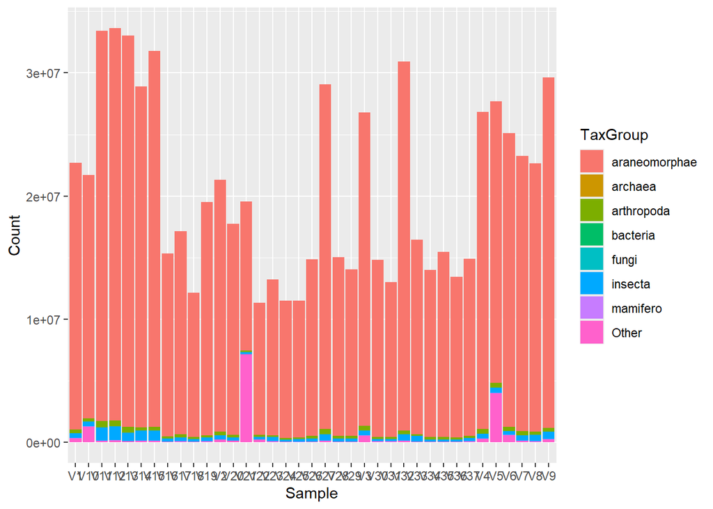

```r
ggplot(bytax,aes(fill=TaxGroup,y=Count,x=Sample)) +
  geom_bar(position="stack",stat="identity")
```

Summarize annotation by taxonomic group

```r
bytax2 <- bytax %>%
  group_by(Sample) %>%
  mutate(
    total_reads = sum(Count, na.rm = TRUE),
    percentage  = 100 * Count / total_reads
  ) %>%
  ungroup()

ci_data <- bytax2 %>%
  group_by(TaxGroup) %>%
  summarise(
    mean_percentage = mean(percentage, na.rm = TRUE),
    sd_percentage   = sd(percentage, na.rm = TRUE),
    n               = n(),
    se              = sd_percentage / sqrt(n),
    lower_CI        = mean_percentage - 1.96 * se,
    upper_CI        = mean_percentage + 1.96 * se
  )

ci_data
```

| TaxGroup | mean_percentage | sd_percentage | n | se | lower_CI | upper_CI |
| --- | --- | --- | --- | --- | --- | --- |
| Other | 2.084709e+00 | 6.319986e+00 | 37 | 1.038999e+00 | 4.827066e-02 | 4.121148e+00 |
| araneomorphae | 9.468064e+01 | 6.077481e+00 | 37 | 9.991318e-01 | 9.272234e+01 | 9.663893e+01 |
| archaea | 1.189158e-04 | 6.440104e-05 | 37 | 1.058747e-05 | 9.816441e-05 | 1.396673e-04 |
| arthropoda | 1.282533e+00 | 2.137961e-01 | 37 | 3.514786e-02 | 1.213644e+00 | 1.351423e+00 |
| bacteria | 2.660863e-04 | 1.140935e-04 | 37 | 1.875685e-05 | 2.293229e-04 | 3.028497e-04 |
| fungi | 1.235079e-03 | 1.517174e-03 | 37 | 2.494218e-04 | 7.462123e-04 | 1.723946e-03 |
| insecta | 1.794141e+00 | 5.873005e-01 | 37 | 9.655161e-02 | 1.604900e+00 | 1.983382e+00 |
| mamifero | 1.563608e-01 | 3.533256e-02 | 37 | 5.808637e-03 | 1.449759e-01 | 1.677458e-01 |

**Our annotation was good! The majority of transcripts in all our samples correspond to Araneomorphae**

# 3 Differential Expression Analyses

To reduce possible contaminants in our analyses, we first will limit our analyses to transcripts which taxonomical association correspond to Araneomorphae, Arthropoda, or Insecta. With these transcripts, we will build three different models in Deseq2.

1. The first model will include all samples using developmental stage as a fixed term.
2. The second model will explore differences between the black-and-white and black colour morphs in juveniles.
3. The third model will examine differences between the black-and-white and black colour morphs in adults.

## 3.1 All samples categorize by developmental stage

**Data filtering**

```r
m <- filter(tab, str_detect(Taxonomic.Lineage, "araneomorphae|arthropoda|insecta"))[,c(1:38)]
```

**Deseq2 model to test using developmental stage as predictor**

```r
tx2gene<-rosetta_stone

#remove txOut=TRUE to make gene level sum

txi <- tximport(list_dir, type = "salmon",ignoreTxVersion = TRUE,tx2gene = tx2gene)

dds <- DESeqDataSetFromTximport(txi, coldata, ~stage)

colnames(dds)<-sample_names

dds<-dds[rownames(dds) %in% m$gene_id,]

dds_stage <- DESeq(dds,minReplicatesForReplace=Inf)
```

**Model result visualization**

PCA will help use to remove outlier samples fro the dataset that might bias the analysis

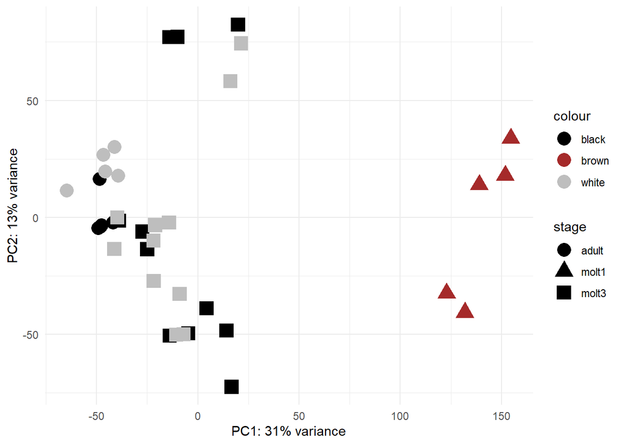

```r
vsdata <- vst(dds_stage, blind = FALSE) ## use instead of vst because of sample size
pcaData <- plotPCA(vsdata, intgroup=c("stage"),ntop=10000, returnData=TRUE)
pcaData$colour<-coldata$colour
percentVar <- round(100 * attr(pcaData, "percentVar"))
ggplot(pcaData, aes(PC1, PC2, shape=stage,col=colour)) +
  #geom_text(label=coldata$sample_names)+
  geom_point(size=5) +
  xlab(paste0("PC1: ",percentVar[1],"% variance")) +
  ylab(paste0("PC2: ",percentVar[2],"% variance")) +
  theme_minimal()+
  scale_colour_manual(values = c("black", "brown", "gray"))
```

It seems that there are five samples at the bottom of the plot that are outliers. We need to remove this samples to properly generate some results.

```r
samples_rm<-c("G14_3_W6","G13_3_W1","G14_3_B4","G14_3_B5","G14_3_B1")

coldata$stage<-factor(coldata$stage,levels = c("molt1","molt3","adult"))

dds <- DESeqDataSetFromTximport(txi, coldata, ~stage)
```

```
## using counts and average transcript lengths from tximport
```

```r
colnames(dds)<-sample_names

dds<-dds[,!colnames(dds) %in% samples_rm]

dds<-dds[rownames(dds) %in% m$gene_id,]
```

Re run the model

```r
dds_stage <- DESeq(dds,minReplicatesForReplace=Inf)
```

```
## using 'avgTxLength' from assays(dds), correcting for library size
```

**Model result visualization**

Let´s see if the visualization of the samples improve

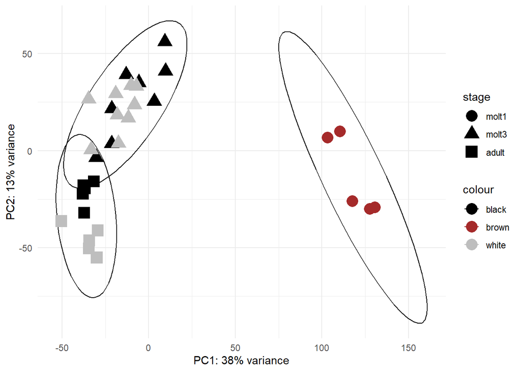

```r
vsdata <- vst(dds_stage, blind = FALSE) ## use instead of vst because of sample size
pcaData <- plotPCA(vsdata, intgroup=c("stage"),ntop=10000, returnData=TRUE)
pcaData$colour<-dds@colData$colour
percentVar <- round(100 * attr(pcaData, "percentVar"))
ggplot(pcaData, aes(PC1, PC2, shape=stage, col=colour)) +
  stat_ellipse(aes(group=factor(stage)), type="norm", level=0.95) +
  geom_point(size=5) +
  xlab(paste0("PC1: ",percentVar[1],"% variance")) +
  ylab(paste0("PC2: ",percentVar[2],"% variance")) +
  theme_minimal() +
  scale_colour_manual(values = c("black", "brown", "gray"))
```

We successfully recover the three developmental stages of our experimental design. A similar plot we get when we explore everything on a heatmap

```r
library("RColorBrewer")
```

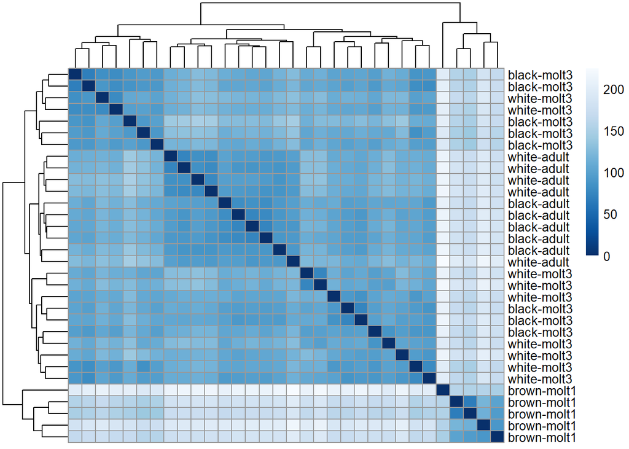

```r
library(pheatmap)
vsd<-vsdata
sampleDists <- dist(t(assay(vsd)))
sampleDistMatrix <- as.matrix(sampleDists)
rownames(sampleDistMatrix) <- paste(vsd$colour,vsd$stage, sep="-")
colnames(sampleDistMatrix) <- NULL
colors <- colorRampPalette( rev(brewer.pal(9, "Blues")) )(255)
pheatmap(sampleDistMatrix,
         clustering_distance_rows=sampleDists,
         clustering_distance_cols=sampleDists,
         col=colors)
```

## 3.2 Colour morph differential expression juveniles

### 3.2.1 data filtering

let´s filter the dataset to include only juveniles

```r
txi <- tximport(list_dir, type = "salmon",ignoreTxVersion = TRUE,tx2gene = tx2gene)

m <- filter(tab, str_detect(Taxonomic.Lineage, "araneomorphae|arthropoda|insecta"))[,c(1:38)]

#colnames(m)<-c(sample_names,"gene_id","Subject.Sequence")

samples_rm<-c("G14_3_W6","G13_3_W1","G14_3_B4","G14_3_B5","G14_3_B1")

coldata$stage<-as.factor(coldata$stage)

m3<-which(coldata$stage == "molt3")

txi_m3 <- lapply(txi, function(x) if(is.matrix(x)) return(x[,m3]) else return(x))

dds <- DESeqDataSetFromTximport(txi_m3, coldata[m3,], ~colour)

colnames(dds)<-sample_names[m3]

dds<-dds[,!colnames(dds) %in% samples_rm]

dds<-dds[rownames(dds) %in% m$gene_id,]
```

Run the model

```r
dds_juveniles <- DESeq(dds,minReplicatesForReplace=Inf)
```

### 3.2.2 Model result visualization

Let´s explore the model

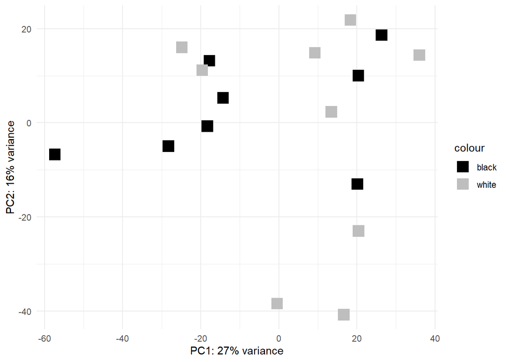

```r
vsdata <- vst(dds_juveniles, blind = FALSE) ## use instead of vst because of sample size
pcaData <- plotPCA(vsdata, intgroup=c("colour"),ntop=1000, returnData=TRUE)
#pcaData$stage<-dds@colData$stage
percentVar <- round(100 * attr(pcaData, "percentVar"))
ggplot(pcaData, aes(PC1, PC2,col=colour)) +
  #geom_text(label=dds_juveniles$sample_names)+
  geom_point(shape = 15,size=5) +
  xlab(paste0("PC1: ",percentVar[1],"% variance")) +
  ylab(paste0("PC2: ",percentVar[2],"% variance")) +
  theme_minimal()+
  scale_colour_manual(values = c("black", "gray"))
```

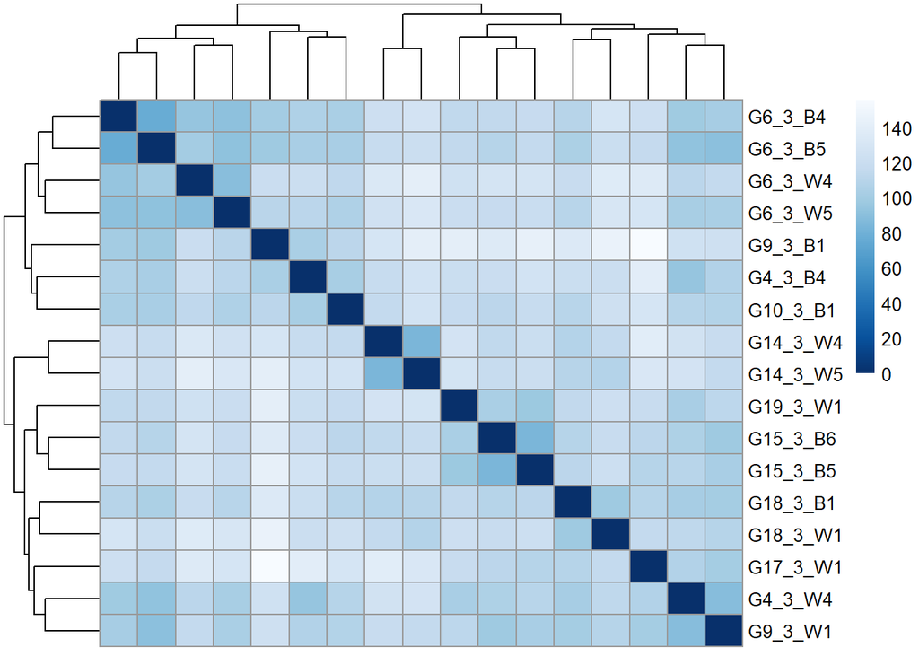

```r
library("RColorBrewer")
library(pheatmap)
vsd<-vsdata
sampleDists <- dist(t(assay(vsd)))
sampleDistMatrix <- as.matrix(sampleDists)
rownames(sampleDistMatrix) <- dds_juveniles$sample_names#paste(vsd$colour,vsd$stage, sep="-")
colnames(sampleDistMatrix) <- NULL
colors <- colorRampPalette( rev(brewer.pal(9, "Blues")) )(255)
pheatmap(sampleDistMatrix,
         clustering_distance_rows=sampleDists,
         clustering_distance_cols=sampleDists,
         col=colors)
```

### 3.2.3 shrunken log2 fold changes

Extract results

```r
res <- results(dds_juveniles, contrast = c('colour', 'black', 'white'))
```

get shrunken log fold changes, specifying the coefficient

```r
res_shrink <- lfcShrink(dds_juveniles, coef="colour_white_vs_black", type="ashr")
```

```
## using 'ashr' for LFC shrinkage. If used in published research, please cite:
##     Stephens, M. (2016) False discovery rates: a new deal. Biostatistics, 18:2.
##     https://doi.org/10.1093/biostatistics/kxw041
```

### 3.2.4 Volcano plot

Plot the differential expressed transcripts with volcano plot. This visualization help to identify patterns of differential expression

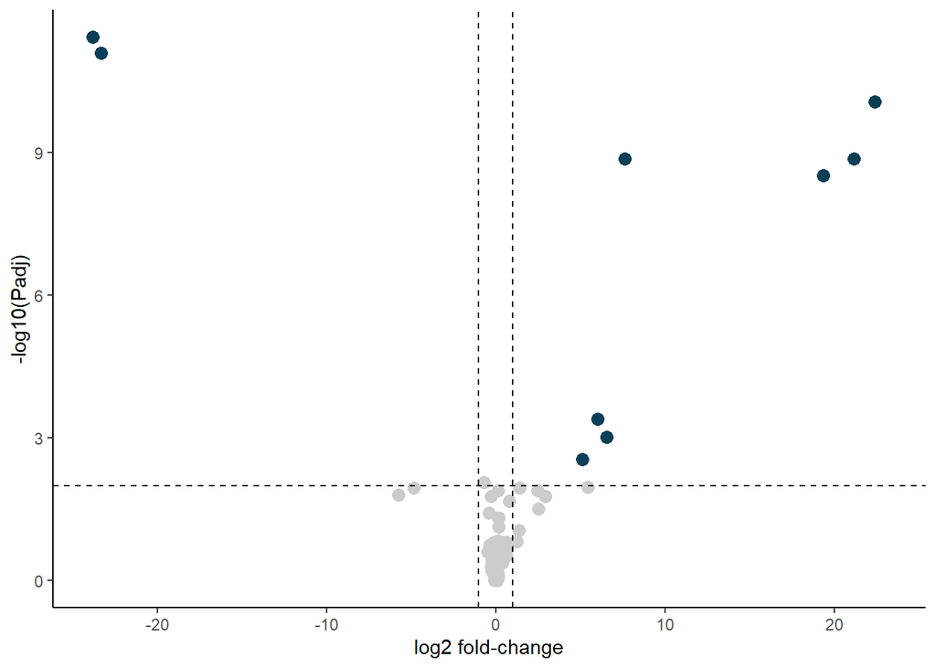

```r
express_values<-as_tibble(res_shrink)
express_values$gene_id<-rownames(res_shrink)

ggplot(data= express_values, aes(x= log2FoldChange, y= -log10(padj))) +
    geom_point(colour= 'grey80',size=3) +
    geom_point(data=express_values[abs(express_values$log2FoldChange) >= 1 & express_values$padj <= 0.01,],aes(x=log2FoldChange, y=(-log10(padj))),colour= '#0A3F55',size=3)+
    geom_vline(xintercept= c(-1, 1), colour= 'black', linetype= 'dashed') +
    geom_hline(yintercept= 2, colour= 'black', linetype= 'dashed') +
    xlab('log2 fold-change') +
    ylab('-log10(Padj)') +
    theme_classic()
```

**It seems that there are not many differential expressed transcripts**

### 3.2.5 MA plot

This plot shows the log2 fold changes over the mean of normalized counts for all the samples

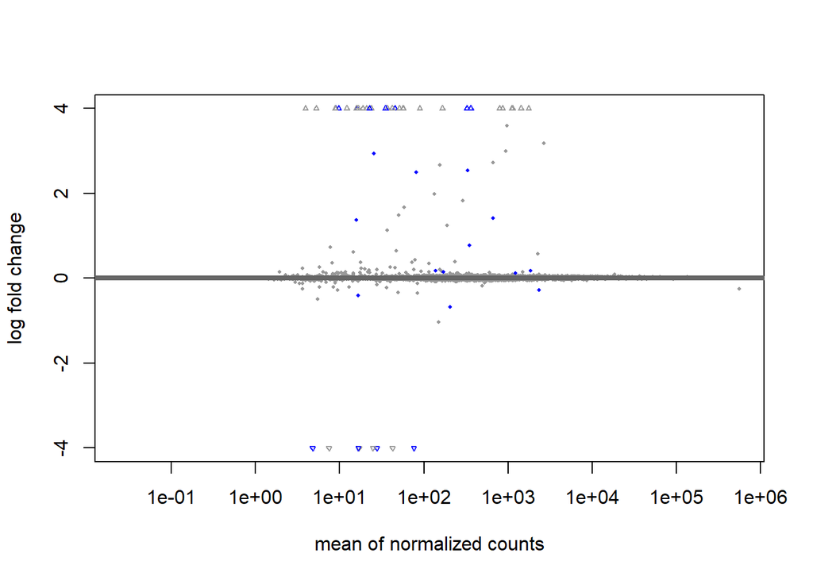

```r
plotMA(res_shrink, ylim=c(-4,4))
```

**It seems that there are not many differential expressed transcripts**

### 3.2.6 Significant expressed transcripts

```r
res_sig005<-res_shrink[which(res_shrink$pvalue<0.05 & res_shrink$padj < 0.01),]
res_sig001<-res_shrink[which(res_shrink$pvalue<0.01 & res_shrink$padj < 0.01),]
nrow(res_sig005)
```

```
## [1] 10
```

```r
nrow(res_sig001)
```

```
## [1] 10
```

```r
diff_m3_res_sig005<-res_sig005
diff_m3_res_sig001<-res_sig001
```

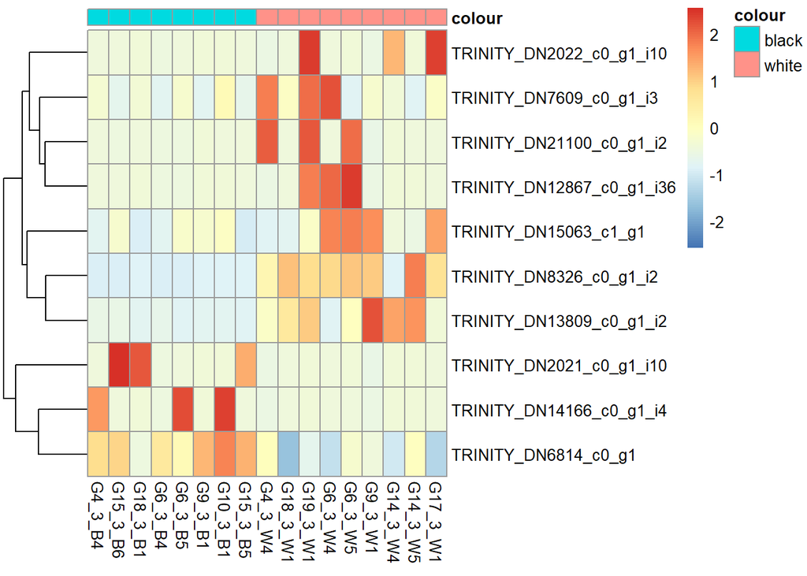

```r
rld_m3 <- rlog(dds_juveniles, blind=FALSE)

# get top 50 log fold change genes (excluding cook's cutoff outliers)
top50_m3 <- data.frame(res_sig005) %>%
  filter(!is.na(padj)) %>%
  arrange(-abs(log2FoldChange)) %>%
  rownames() %>%
  head(.,n=10)

df <- data.frame(colData(dds_juveniles)[,"colour"])
rownames(df) <- colnames(dds_juveniles)
colnames(df) <- "colour"

pheatmap(
  assay(rld_m3)[top50_m3,],
  cluster_rows=TRUE,
  show_rownames=TRUE,
  cluster_cols=FALSE,
  annotation_col=df,
  scale = 'row'
)
```

**This plot confirms that there is not clear pattern of differtial expression betwen black-and-whit and black juveniles**

Let’s get the DE transcripts using an alpha of 0.01

```r
res_sig<-res_shrink

de_export<-res_shrink[which(res_shrink$pvalue<0.05 & res_shrink$padj<0.01),]

de_export<-as.data.frame(de_export)
de_export$gene_id<-rownames(de_export)

write_csv(de_export,"sigDE_juveniles.txt")

res2 <- cbind(gene_id=rownames(res_sig),res_sig) %>%
  data.frame() %>%
  filter(!is.na(padj))

res2 <- inner_join(res2,tab,by="gene_id")
```

Get the length of the transcripts for the correction with goseq

```r
# vector of transcript lengths
tran_length<-len
names(tran_length)<-c("gene_id","len")

res2 <- inner_join(res2,tran_length,by="gene_id")
res2_unique <- res2[!duplicated(res2$gene_id), ]

de <- res2_unique$pvalue<0.05 & res2_unique$padj < 0.01
names(de) <- res2_unique$gene_id
```

mapping of transcript IDs to category IDs

```r
#GOmap <- read.table("../annotation_m1_m3_a/final_results/annotated_gene_ontology_terms.tsv",sep="\t",quote="",comment.char="",header=TRUE) %>%
#  mutate(gene_id=str_remove(query_sequence, ".p[0-9]+$"))
```

match transcripts with GO terms

```r
go <- data.frame(GOmap[,c(5,2)]) %>% filter(gene_id %in% res2_unique$gene_id)
```

With this object we can start the analysis

### 3.2.7 analysis

Account for transcript length bias by calculating the probability of being DE based purely on gene length

```r
de_subset<-res2_unique[which(de==TRUE),]
mypwf <- nullp(DEgenes=de,bias.data=res2_unique$len)
```

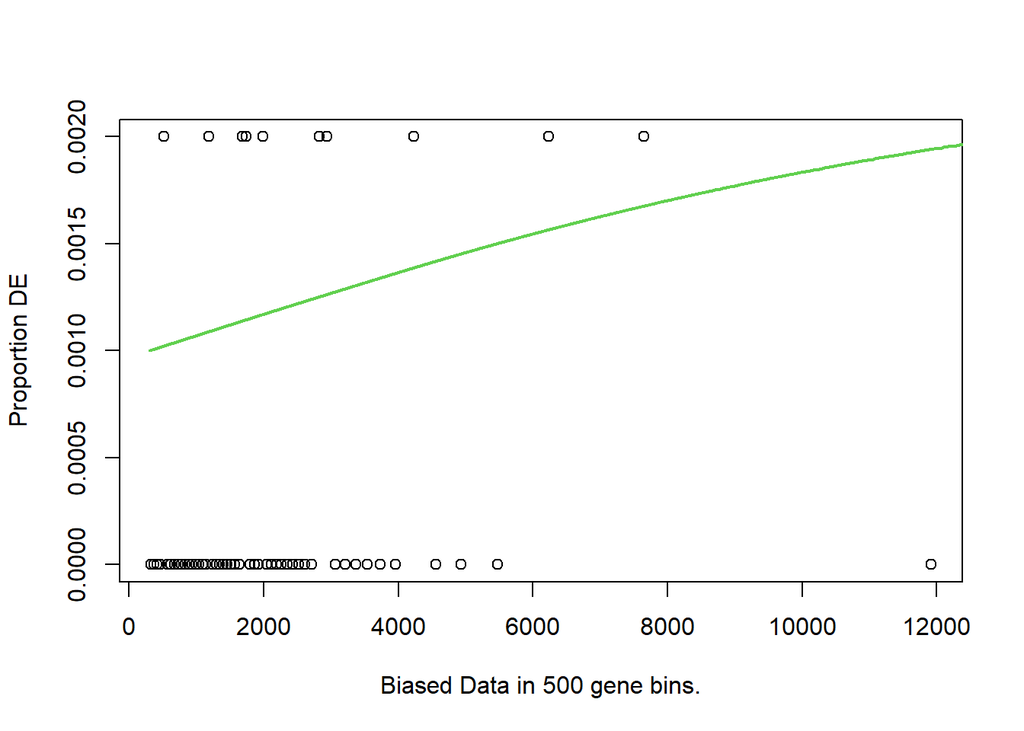

```r
GO.wall <- goseq(pwf=mypwf,gene2cat=go)
```

False discovery rate correction on p-values using Benjamini-Hochberg

```r
GO.wall <- cbind(
  GO.wall,
  padj_overrepresented=p.adjust(GO.wall$over_represented_pvalue, method="BH"),
  padj_underrepresented=p.adjust(GO.wall$under_represented_pvalue, method="BH")
)
```

Names of GO terms

```r
sig_go<-GO.wall[which(GO.wall$padj_overrepresented < 0.001),c("category","term","over_represented_pvalue","padj_overrepresented")]

write_excel_csv(sig_go,"sig_go_m3.csv")
```

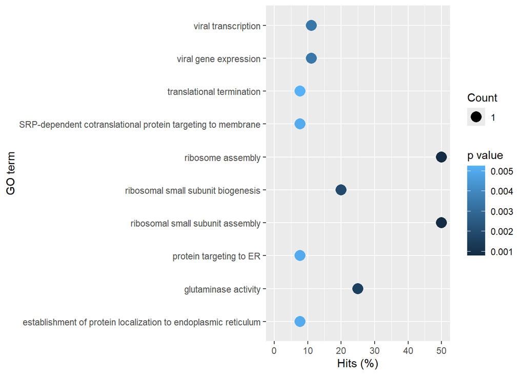

```r
GO.wall %>%
  top_n(10, wt=-over_represented_pvalue) %>%
  mutate(hitsPerc=numDEInCat*100/numInCat) %>%
  ggplot(aes(x=hitsPerc,
             y=term,
             colour=over_represented_pvalue,
             size=numDEInCat)) +
  geom_point() +
  expand_limits(x=0) +
  labs(x="Hits (%)", y="GO term", colour="p value", size="Count")
```

## 3.3 Colour morph differential expression adults

### 3.3.1 data filtering

```r
txi <- tximport(list_dir, type = "salmon",ignoreTxVersion = TRUE,tx2gene = tx2gene)

m <- filter(tab, str_detect(Taxonomic.Lineage, "araneomorphae|arthropoda|insecta"))[,c(1:38)]

#colnames(m)<-c(sample_names,"gene_id","Subject.Sequence")

coldata$stage<-as.factor(coldata$stage)

adult<-which(coldata$stage == "adult")

txi_adult <- lapply(txi, function(x) if(is.matrix(x)) return(x[,adult]) else return(x))

dds <- DESeqDataSetFromTximport(txi_adult, coldata[adult,], ~colour)

colnames(dds)<-sample_names[adult]

#dds<-dds[,!colnames(dds) %in% samples_rm]

dds<-dds[rownames(dds) %in% m$gene_id,]
```

run the model

```r
dds_adults <- DESeq(dds,minReplicatesForReplace=Inf)
```

### 3.3.2 Model result visualization

Let´s explore the model

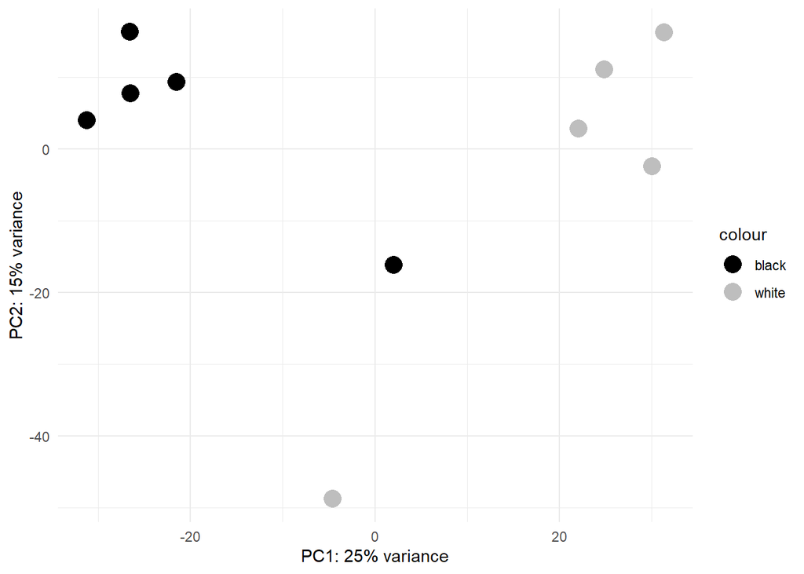

```r
vsdata <- vst(dds_adults, blind = FALSE) ## use instead of vst because of sample size
pcaData <- plotPCA(vsdata, intgroup=c("colour"),ntop=10000, returnData=TRUE)
#pcaData$stage<-dds@colData$stage
percentVar <- round(100 * attr(pcaData, "percentVar"))
ggplot(pcaData, aes(PC1, PC2,col=colour)) +
  #geom_text(label=dds_adults@colData$sample_names)+
  geom_point(size=5) +
  xlab(paste0("PC1: ",percentVar[1],"% variance")) +
  ylab(paste0("PC2: ",percentVar[2],"% variance")) +
  theme_minimal()+
  scale_colour_manual(values = c("black", "gray"))
```

It seems that there are two samples *G25_A_B7* and *G26_A_W1* that are outliers. Let’s remove them for further analyses.

### 3.3.3 Remove outlier samples

```r
txi <- tximport(list_dir, type = "salmon",ignoreTxVersion = TRUE,tx2gene = tx2gene)

m <- filter(tab, str_detect(Taxonomic.Lineage, "araneomorphae|arthropoda|insecta"))[,c(1:38)]

#colnames(m)<-c(sample_names,"gene_id","Subject.Sequence")

samples_rm<-c("G25_A_B7","G26_A_W1")

coldata$stage<-as.factor(coldata$stage)

adult<-which(coldata$stage == "adult")

txi_adult <- lapply(txi, function(x) if(is.matrix(x)) return(x[,adult]) else return(x))

dds <- DESeqDataSetFromTximport(txi_adult, coldata[adult,], ~colour)

colnames(dds)<-sample_names[adult]

dds<-dds[,!colnames(dds) %in% samples_rm]

dds<-dds[rownames(dds) %in% m$gene_id,]
```

Re run the model

```r
dds_adults <- DESeq(dds,minReplicatesForReplace=Inf)
```

### 3.3.4 Model result visualization

Let´s explore the model

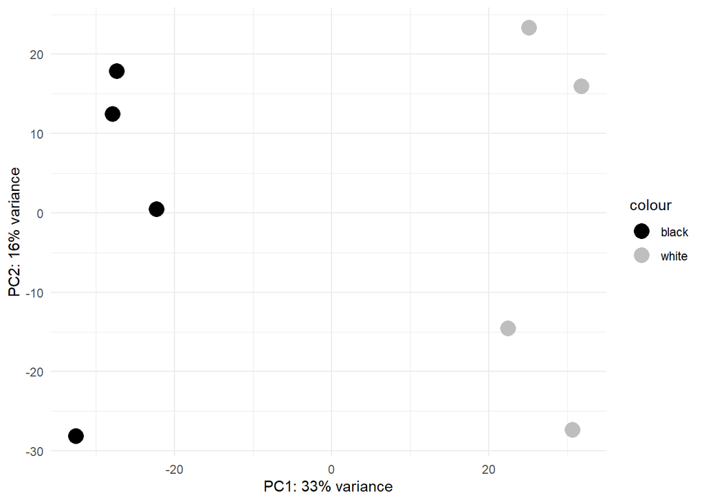

```r
vsdata <- vst(dds_adults, blind = FALSE) ## use instead of vst because of sample size
pcaData <- plotPCA(vsdata, intgroup=c("colour"),ntop=10000, returnData=TRUE)
#pcaData$stage<-dds@colData$stage
percentVar <- round(100 * attr(pcaData, "percentVar"))
ggplot(pcaData, aes(PC1, PC2,col=colour)) +
  #geom_text(label=dds_adults@colData$sample_names)+
  geom_point(size=5) +
  xlab(paste0("PC1: ",percentVar[1],"% variance")) +
  ylab(paste0("PC2: ",percentVar[2],"% variance")) +
  theme_minimal()+
  scale_colour_manual(values = c("black", "gray"))
```

Here the differentiation on the PC1 between black-and-white and black is clear!

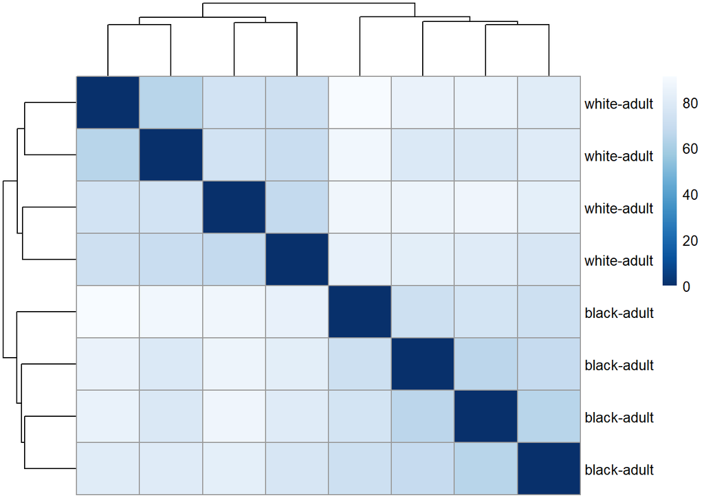

```r
library("RColorBrewer")
library(pheatmap)
vsd<-vsdata
sampleDists <- dist(t(assay(vsd)))
sampleDistMatrix <- as.matrix(sampleDists)
rownames(sampleDistMatrix) <- paste(vsd$colour,vsd$stage, sep="-")
colnames(sampleDistMatrix) <- NULL
colors <- colorRampPalette( rev(brewer.pal(9, "Blues")) )(255)
pheatmap(sampleDistMatrix,
         clustering_distance_rows=sampleDists,
         clustering_distance_cols=sampleDists,
         col=colors)
```

### 3.3.5 shrunken log2 fold changes

Extract results

```r
res <- results(dds_adults, contrast = c('colour', 'black', 'white'))
```

get shrunken log fold changes, specifying the coefficient

```r
res_shrink <- lfcShrink(dds_adults, coef="colour_white_vs_black", type="ashr")
```

```
## using 'ashr' for LFC shrinkage. If used in published research, please cite:
##     Stephens, M. (2016) False discovery rates: a new deal. Biostatistics, 18:2.
##     https://doi.org/10.1093/biostatistics/kxw041
```

### 3.3.6 Volcano plot

Plot the differential expressed transcripts with volcano plot. This visualization help to indetify patterns of differential expression

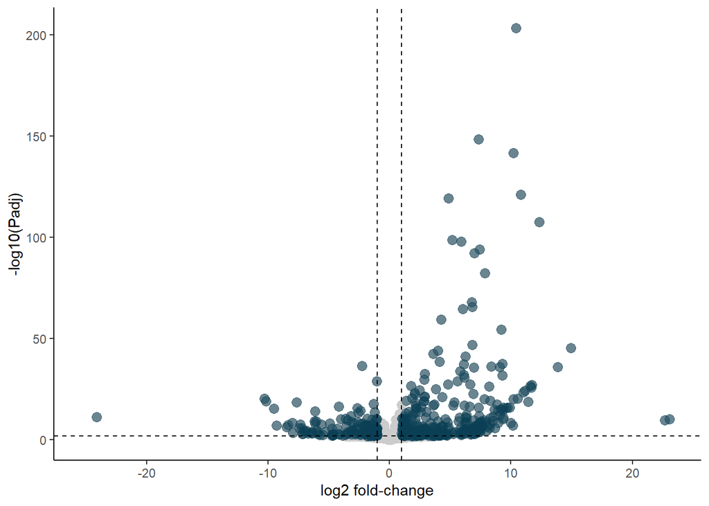

```r
express_values<-as_tibble(res_shrink)
express_values$gene_id<-rownames(res_shrink)

ggplot(data= express_values, aes(x= log2FoldChange, y= -log10(padj))) +
    geom_point(colour= 'grey80',size=3) +
    geom_point(data=express_values[abs(express_values$log2FoldChange) >= 1 & express_values$padj <= 0.01,],aes(x=log2FoldChange, y=(-log10(padj))),colour= '#0A3F55',size=3,alpha=0.5)+
    geom_vline(xintercept= c(-1, 1), colour= 'black', linetype= 'dashed') +
    geom_hline(yintercept= 2, colour= 'black', linetype= 'dashed') +
    xlab('log2 fold-change') +
    ylab('-log10(Padj)') +
    theme_classic()
```

### 3.3.7 MA plot

This plot shows the log2 fold changes over the mean of normalized counts for all the samples

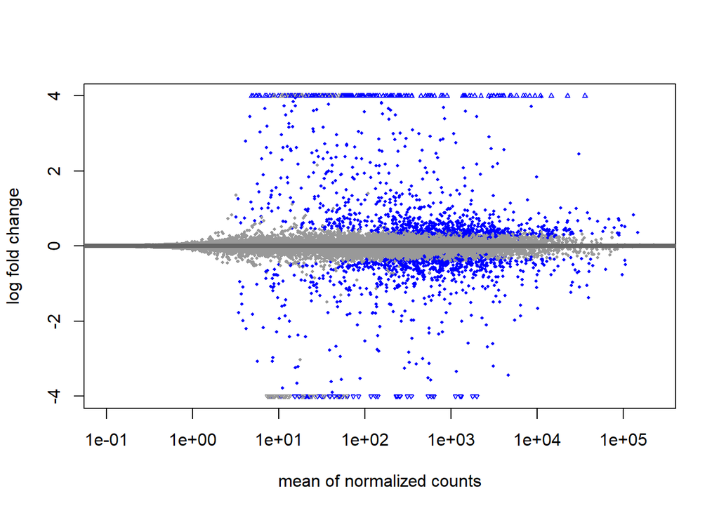

```r
plotMA(res_shrink, ylim=c(-4,4))
```

**It seems that there are many expressed transcripts**

### 3.3.8 Significant expressed transcripts

```r
res_sig005<-res_shrink[which(res_shrink$padj < 0.01),]
res_sig001<-res_shrink[which(res_shrink$padj < 0.01),]
nrow(res_sig005)
```

```
## [1] 814
```

```r
nrow(res_sig001)
```

```
## [1] 814
```

**There are 814 DE transcripts depending on the P-value threshold**

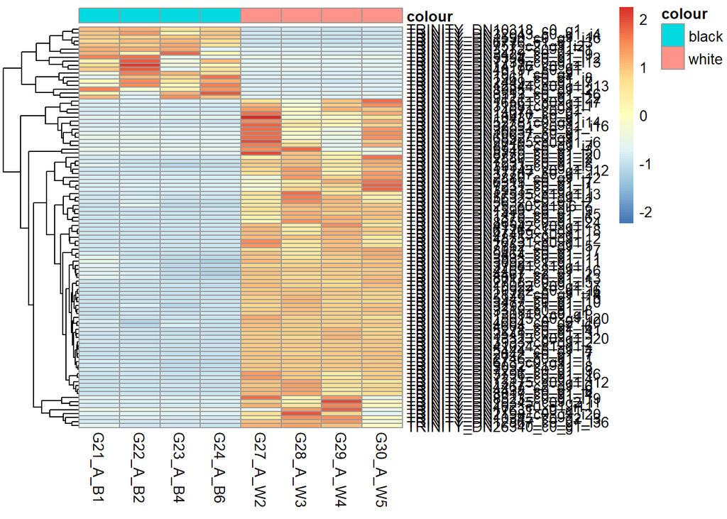

```r
rld_adults <- rlog(dds_adults, blind=FALSE)

# get top 100 log fold change genes (excluding cook's cutoff outliers)
top100_adults <- data.frame(res_sig005) %>%
  filter(!is.na(padj)) %>%
  arrange(-abs(log2FoldChange)) %>%
  rownames() %>%
  head(.,n=100)

df <- data.frame(colData(dds_adults)[,"colour"])
rownames(df) <- colnames(dds_adults)
colnames(df) <- "colour"

pheatmap(
  assay(rld_adults)[top100_adults,],
  cluster_rows=TRUE,
  show_rownames=TRUE,
  cluster_cols=FALSE,
  annotation_col=df,
  scale='row'
  #,labels_row=ann[ann$Query.Sequence %in% top50_adults,]$Description
)
```

**This plot shows a clear pattern where the black-and-white individuals express more certain transcripts compared to the black individuals**

## 3.4 Gene ontology adults

### 3.4.1 input objects

Let’s get the DE transcripts using an alpha of 0.01

```r
res_sig<-res_shrink

de_export<-res_shrink[which(res_shrink$padj<0.01),]
#de_export<-de_export[which(de_export$log2FoldChange<=(-1) | de_export$log2FoldChange>=1),]
de_export<-as.data.frame(de_export)
de_export$gene_id<-rownames(de_export)

write_csv(de_export,"sigDE_adults.txt")

res2 <- cbind(gene_id=rownames(res_sig),res_sig) %>%
  data.frame() %>%
  filter(!is.na(padj))

res2 <- inner_join(res2,tab,by="gene_id")
```

There 814 differential expressed transcripts

Get the length of the transcripts for the correction with goseq

```r
# vector of transcript lengths
tran_length<-len
names(tran_length)<-c("gene_id","len")

res2 <- inner_join(res2,tran_length,by="gene_id")

res2_unique <- res2[!duplicated(res2$gene_id), ]

de <- res2_unique$pvalue<0.05 & res2_unique$padj < 0.01
names(de) <- res2_unique$gene_id
```

mapping of transcript IDs to category IDs

```r
GOmap <- read.table("../annotation_m1_m3_a/final_results/annotated_gene_ontology_terms.tsv",sep="\t",quote="",comment.char="",header=TRUE) %>%
 mutate(gene_id=query_sequence)

#number of DE with GO annottion
length(which(de_export$gene_id %in% GOmap$gene_id))
```

```
## [1] 287
```

```r
#modify to include GO terms in file considering are summary in annotation
length(which(!de_export$gene_id %in% rosetta_stone$transcript))
```

```
## [1] 423
```

```r
#there are 423 expressed "genes" that wont be represented in the GOmap, let's fix that
genes<-de_export$gene_id[which(!de_export$gene_id %in% rosetta_stone$transcript)]

transcripts<-rosetta_stone$transcript[which(rosetta_stone$gene %in% genes)]

GOmap_extra<-GOmap %>%
  filter(gene_id %in% transcripts) %>%
  mutate(gene_id = str_remove(gene_id, "_i\\d+$"))

GOmap<-rbind(GOmap,GOmap_extra)

#confirm that the transcript with annotation is higher, it went from 287 to 568
length(which(de_export$gene_id %in% GOmap$gene_id))
```

```
## [1] 568
```

match transcripts with GO terms

```r
go <- data.frame(GOmap[,c(5,2)]) %>% filter(gene_id %in% res2_unique$gene_id)
```

With this object we can start the analysis

### 3.4.2 analysis

Account for transcript length bias by calculating the probability of being DE based purely on gene length

```r
mypwf <- nullp(DEgenes=de,bias.data=res2_unique$len)
```

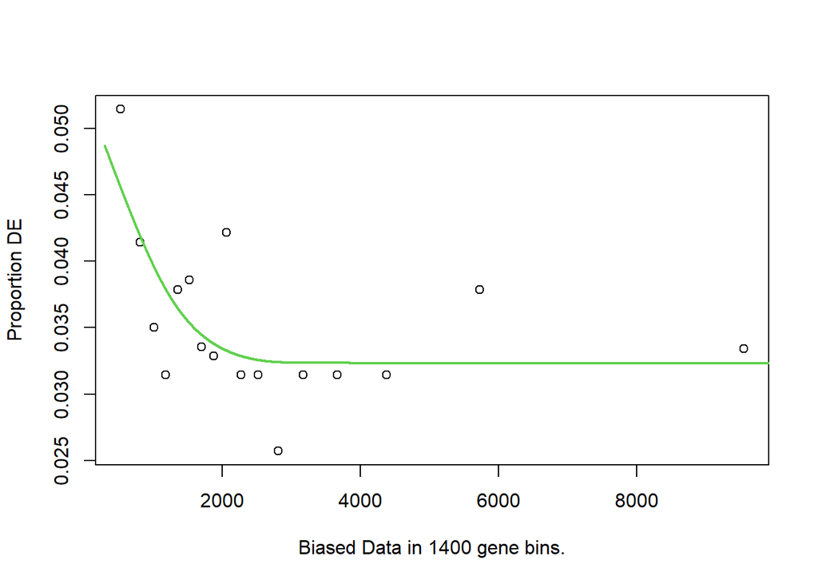

```r
GO.wall <- goseq(pwf=mypwf,gene2cat=go)
```

False discovery rate correction on p-values using Benjamini-Hochberg

```r
GO.wall <- cbind(
  GO.wall,
  padj_overrepresented=p.adjust(GO.wall$over_represented_pvalue, method="BH"),
  padj_underrepresented=p.adjust(GO.wall$under_represented_pvalue, method="BH")
)
```

Names of GO terms

```r
sig_go<-GO.wall[which(GO.wall$padj_overrepresented < 0.001),c("category","term","over_represented_pvalue","padj_overrepresented")]

write_excel_csv(sig_go,"sig_go.csv")
```

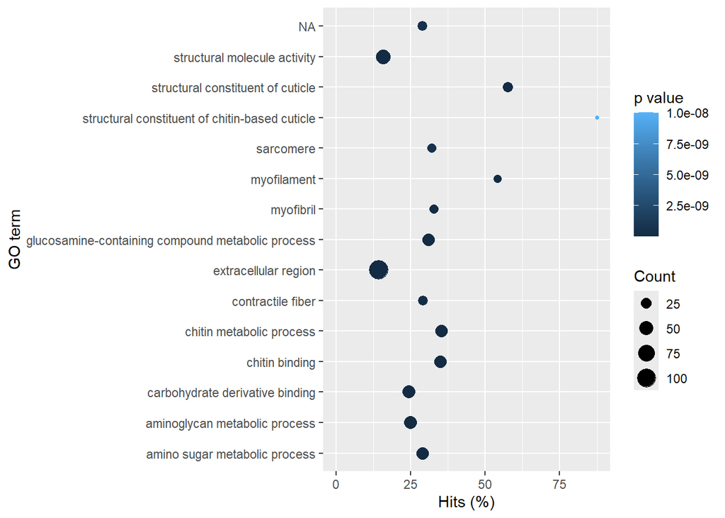

```r
GO.wall %>%
  top_n(15, wt=-over_represented_pvalue) %>%
  mutate(hitsPerc=numDEInCat*100/numInCat) %>%
  ggplot(aes(x=hitsPerc,
             y=term,
             colour=over_represented_pvalue,
             size=numDEInCat)) +
  geom_point() +
  expand_limits(x=0) +
  labs(x="Hits (%)", y="GO term", colour="p value", size="Count")
```

### GO terms of interest

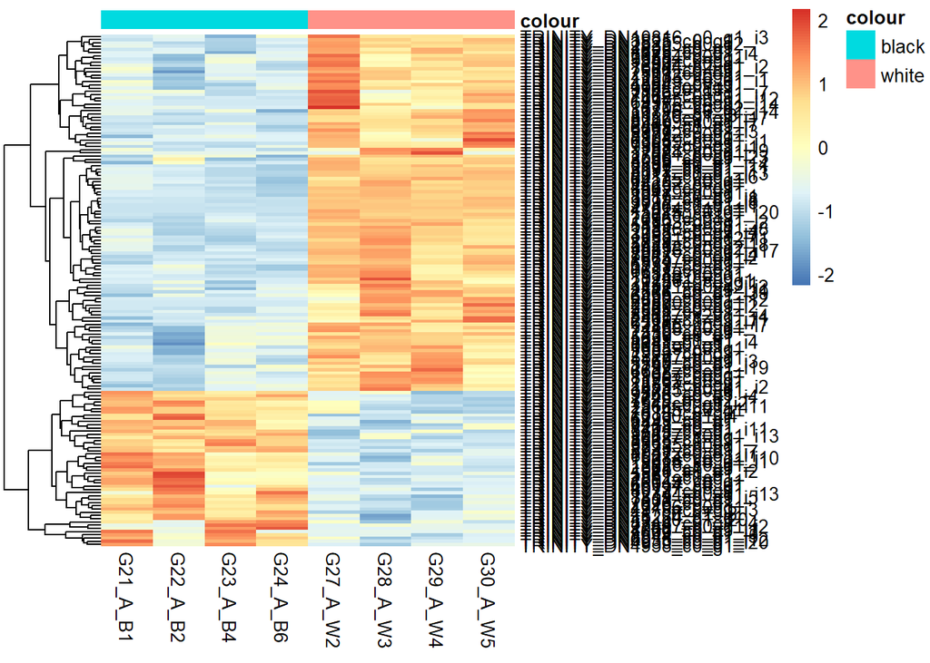

```r
top10_go<-GO.wall %>% top_n(10, wt=-over_represented_pvalue)

de_go_transcripts<-tibble(gene_id=character(),go=character(),term=character())

for(go_term in 1:nrow(top10_go)){

  gene_id<-go[which(go$go_id == top10_go$category[go_term]),"gene_id"]

  de_go<-gene_id[which(gene_id %in% de_export$gene_id)]

  tmp<-tibble(gene_id=de_go,go=top10_go$category[go_term],term=top10_go$term[go_term])

  de_go_transcripts<-rbind(de_go_transcripts,tmp)
}

de_go_unique<-unique(de_go_transcripts)

pheatmap(
  assay(rld_adults)[rownames(rld_adults) %in% de_go_unique$gene_id,],
  cluster_rows=TRUE,
  show_rownames=TRUE,
  cluster_cols=FALSE,
  annotation_col=df,
  scale='row'
  #labels_row=ann[ann$Query.Sequence %in% top50_adults,]$Description
)
```

fold change top10 goterms

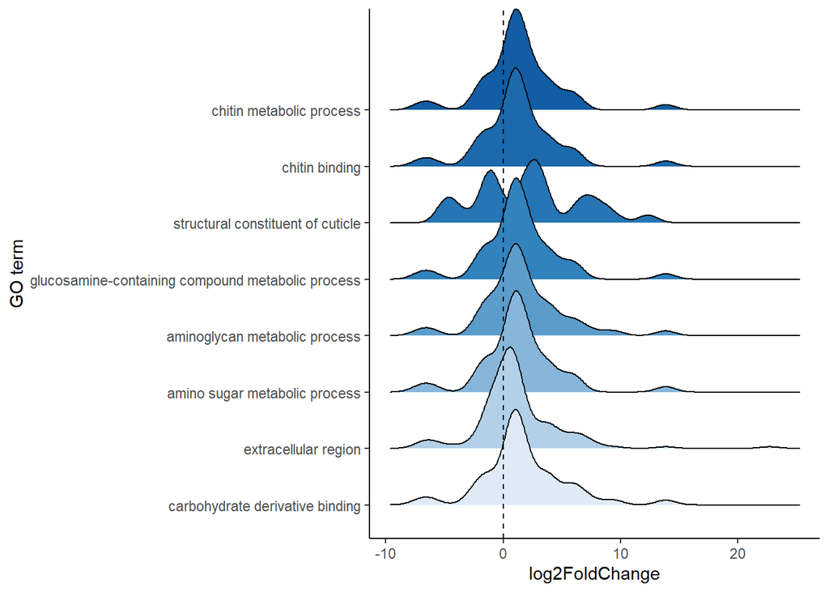

```r
de_go_transcripts<- de_go_transcripts %>% mutate(log2FoldChange= as.numeric(NA))

de_go_transcripts<- de_go_transcripts %>% mutate(padj= as.numeric(NA))

for(tt in 1:nrow(de_go_transcripts)){
  pos<-which(de_export$gene_id %in% de_go_transcripts$gene_id[tt])
  #pos<-grep(de_go_transcripts$gene_id[tt],de_export$gene_id)
  de_go_transcripts$log2FoldChange[tt]<-de_export[pos,"log2FoldChange"]
  de_go_transcripts$padj[tt]<-de_export[pos,"padj"]
}

de_go_transcripts$term<-factor(de_go_transcripts$term,levels = rev(c("chitin metabolic process","chitin binding","structural constituent of cuticle", "glucosamine-containing compound metabolic process","aminoglycan metabolic process","amino sugar metabolic process","extracellular region","carbohydrate derivative binding","myofibril","contractile fiber")))

na.omit(de_go_transcripts) %>%
  ggplot(aes(y = term, x = log2FoldChange, fill = term)) +
  ggridges::geom_density_ridges() +
  theme_classic() +
  geom_vline(xintercept = 0, linetype = "dashed", col = "black", size = 0.4) +
  labs(x = "log2FoldChange", y = "GO term") +
  scale_fill_manual(values = colorRampPalette(c("#deebf7", "#3182bd", "#08519c"))(length(unique(de_go_transcripts$term)))) +
  guides(fill = "none")
```

Chitin and cuticle transcripts

```r
cuticle_chitin<-GO.wall %>% top_n(15, wt=-over_represented_pvalue) %>% filter(term %in% c("chitin metabolic process","chitin binding","structural constituent of cuticle", "glucosamine-containing compound metabolic process","aminoglycan metabolic process", "structural constituent of chitin-based cuticle")) #GO:0005214

de_go<-go[go$gene_id %in% de_export$gene_id,]

de_go[de_go$go_id %in% cuticle_chitin$category,] %>% dim()
```

```
## [1] 213   2
```

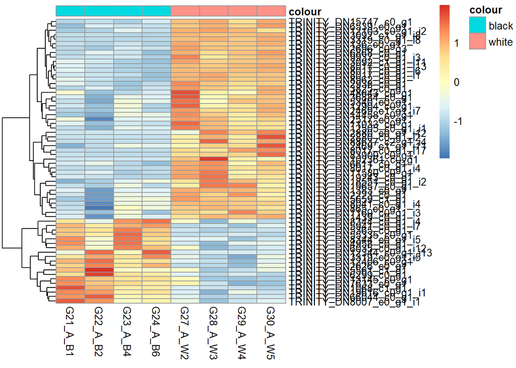

```r
de_go_transcripts<-tibble(gene_id=character(),go=character())

cuticle_transcripts<-de_go[de_go$go_id %in% cuticle_chitin$category,]

for(go_term in 1:nrow(cuticle_chitin)){

gene_id<-go[which(go$go_id == cuticle_chitin$category[go_term]),"gene_id"]

de_go<-gene_id[which(gene_id %in% de_export$gene_id)]

tmp<-tibble(gene_id=de_go,go=cuticle_chitin$category[go_term])

de_go_transcripts<-rbind(de_go_transcripts,tmp)
}


##identify transcripts associated with cuticle/chitin, but with not ontology identification
non_identify<-de_export$transcript_id[which(de_export$gene_id %in% gene_id == FALSE)]

for(tran in non_identify){
  cond<-grep("cutic|chitin",ann[grep(tran,ann$Query.Sequence),"Description"])
  if(length(cond)>0){
    tmp<-tibble(transcript_id=tran,go="blast_match")
    de_go_transcripts<-rbind(de_go_transcripts,tmp)
  } else {next}
}


##unique transcripts
de_go_transcripts_unique <- de_go_transcripts %>%
  group_by(gene_id) %>%
  summarize(
    transcript_id = paste(unique(gene_id), collapse = " "),
    go = paste(unique(go), collapse = " "),
    .groups = "drop"
  )

pheatmap(
  assay(rld_adults)[rownames(rld_adults) %in% de_go_transcripts_unique$gene_id,],
  cluster_rows=TRUE,
  show_rownames=TRUE,
  cluster_cols=FALSE,
  annotation_col=df,
  scale='row'
  #labels_row=ann[ann$Query.Sequence %in% top50_adults,]$Description
)
```

build own volcano plot with custom colours

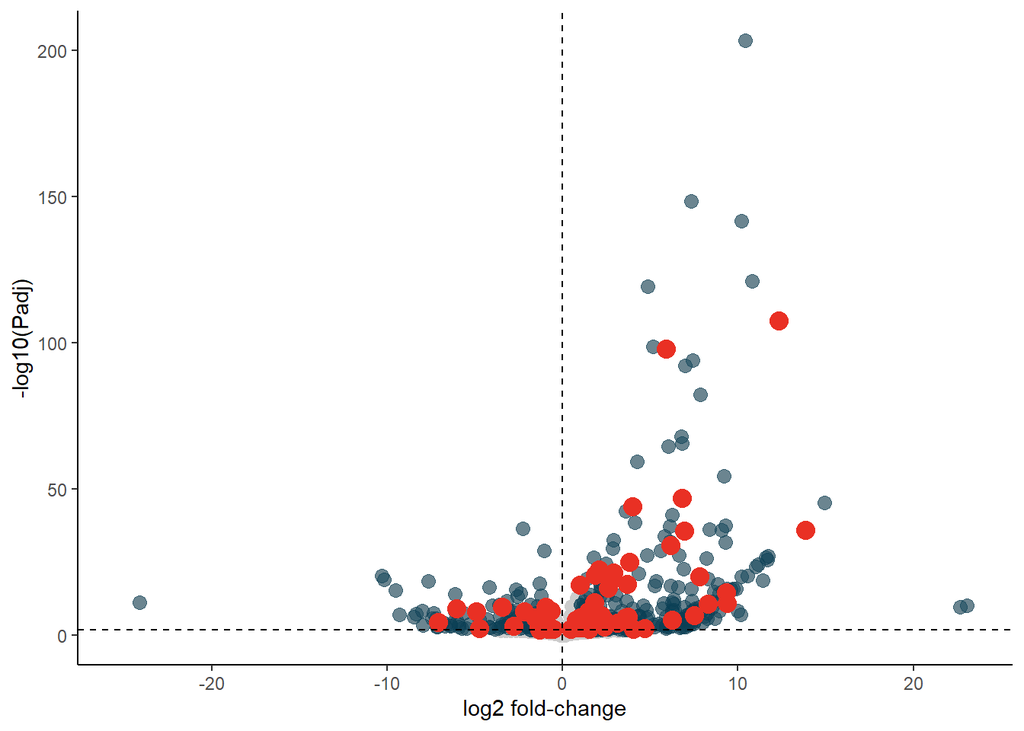

```r
express_values<-as_tibble(res_shrink)
express_values$gene_id<-rownames(res_shrink)
##specify colours
express_values<-express_values %>% mutate(colour=if_else(gene_id %in% de_go_transcripts_unique$gene_id, "red", NA_character_))


ggplot(data= express_values, aes(x= log2FoldChange, y= -log10(padj))) +
    geom_point(colour= 'grey80',size=3) +
    geom_point(data=express_values[abs(express_values$log2FoldChange) >= 1 & express_values$padj <= 0.01,],aes(x=log2FoldChange, y=(-log10(padj))),colour= '#0A3F55',size=3,alpha=0.5)+
    geom_point(data= express_values[!is.na(express_values$colour) & abs(express_values$log2FoldChange) > 0 & express_values$padj <= 0.01,],aes(x=log2FoldChange, y=(-log10(padj))),colour= '#E93024',size=4) +
    geom_vline(xintercept= 0, colour= 'black', linetype= 'dashed') +
    geom_hline(yintercept= 2, colour= 'black', linetype= 'dashed') +
    xlab('log2 fold-change') +
    ylab('-log10(Padj)') +
    theme_classic()
```

#### 3.4.2.1 Melanin

##### 3.4.2.1.1 Juveniles

```r
de_juveniles<-read_csv("sigDE_juveniles.txt")
transcript_go_melanin<-go[grep("GO:0006582",ann$EggNOG.GO.Biological),"gene_id"]

#transcript_go_melanin<-go[grep("GO:0006582",ann$EggNOG.GO.Biological),"gene_id"]

sig_melanin<-transcript_go_melanin[which(transcript_go_melanin %in% de_juveniles$gene_id)]

length(sig_melanin)
```

```
## [1] 0
```

##### 3.4.2.1.2 Adults

```r
sig_melanin<-de_export[which(de_export$gene_id %in% transcript_go_melanin),]

nrow(sig_melanin)
```

```
## [1] 1
```

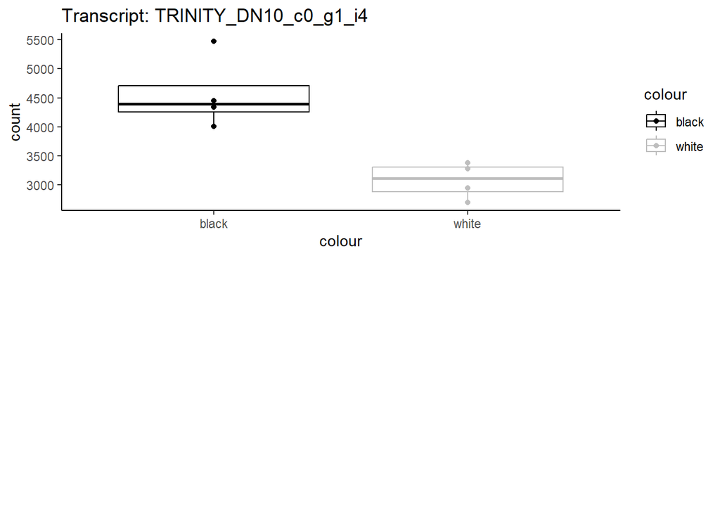

```r
plots <- list()  # To store all plots
for (tt in rownames(sig_melanin)) {
  data <- plotCounts(dds_adults, gene = tt, intgroup = c("colour"), returnData = TRUE)
  p <- ggplot(data, aes(x=colour, y=count, col=colour)) +
    geom_boxplot() +
    geom_point() +
    scale_colour_manual(values = c("black", "gray")) +
    theme_classic()+
    ggtitle(paste("Transcript:", tt))
  plots[[tt]] <- p  # Add the plot to the list
}

# Display two plots at a time in a grid
do.call(grid.arrange, c(plots, nrow = 2))
```

```r
#TRINITY_DN10_c0_g1_i4=XP_055946152.1 cation-independent mannose-6-phosphate receptor-like
```

#### 3.4.2.2 Ommochromes

##### 3.4.2.2.1 Juveniles

```r
de_juveniles<-read_csv("sigDE_juveniles.txt")
transcript_go_ommochrome<-go[grep("GO:0046152",ann$EggNOG.GO.Biological),"gene_id"]

sig_ommo_juv<-transcript_go_ommochrome[which(transcript_go_ommochrome %in% de_juveniles$gene_id)]

length(sig_ommo_juv)
```

```
## [1] 1
```

```r
#"TRINITY_DN14166_c0_g1_i4"=polyadenylate-binding protein 2-like isoform X2 [Argiope bruennichi]
```

##### 3.4.2.2.2 Adults

```r
sig_ommo_adults<-de_export[which(rownames(de_export) %in% transcript_go_ommochrome),]

nrow(sig_ommo_adults)
```

```
## [1] 1
```

```r
#identity: TRINITY_DN32391_c0_g1_i16=Serine/threonine-protein kinase
```

## 3.6 Normalized counts melanin associated transcripts

### 3.6.1 Juveniles

```r
melanin_transcripts<-c("TRINITY_DN11796_c0_g1_i4","TRINITY_DN447_c0_g2_i1","TRINITY_DN1136_c0_g1_i1","TRINITY_DN119_c0_g1_i6","TRINITY_DN2896_c0_g2_i2","TRINITY_DN23627_c0_g1_i2","TRINITY_DN47018_c0_g1_i1")

melano_ids <- tibble(
  original = melanin_transcripts,
  stripped = str_remove(melanin_transcripts, "_i\\d+$")
)

sig_melanin <- tibble(
  bind_cols(as_tibble(de_juveniles)) %>%        # add DE table columns
  filter(gene_id %in% melano_ids$original |
         gene_id %in% melano_ids$stripped))

nrow(sig_melanin)
```

```
## [1] 0
```

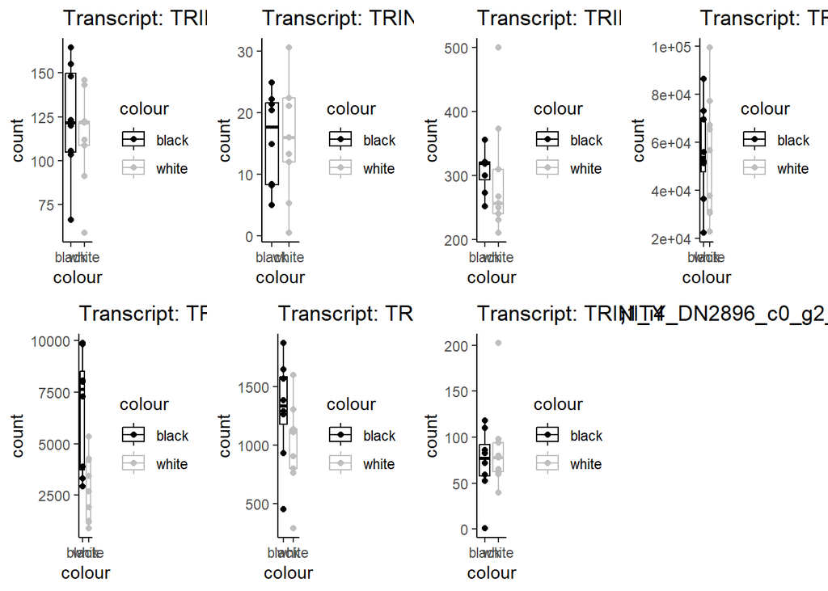

```r
melanin_annotated<-tx2gene$gene[tx2gene$transcript %in% melanin_transcripts]

plots <- list()  # To store all plots
for (tt in melanin_annotated) {
  data <- plotCounts(dds_juveniles, gene = tt, intgroup = c("colour"), returnData = TRUE)
  p <- ggplot(data, aes(x=colour, y=count, col=colour)) +
    geom_boxplot() +
    geom_point() +
    scale_colour_manual(values = c("black", "gray")) +
    theme_classic()+
    ggtitle(paste("Transcript:", tt))
  plots[[tt]] <- p  # Add the plot to the list
}




# Display two plots at a time in a grid
do.call(grid.arrange, c(plots, nrow = 2))
```

### 3.6.2 Adults

```r
melanin_transcripts<-c("TRINITY_DN11796_c0_g1_i4","TRINITY_DN447_c0_g2_i1","TRINITY_DN1136_c0_g1_i1","TRINITY_DN119_c0_g1_i6","TRINITY_DN2896_c0_g2_i2","TRINITY_DN23627_c0_g1_i2","TRINITY_DN47018_c0_g1_i1")

melano_ids <- tibble(
  original = melanin_transcripts,
  stripped = str_remove(melanin_transcripts, "_i\\d+$")
)

sig_melanin <- tibble(
  bind_cols(as_tibble(de_export)) %>%        # add DE table columns
  filter(gene_id %in% melano_ids$original |
         gene_id %in% melano_ids$stripped))

nrow(sig_melanin)
```

```
## [1] 1
```

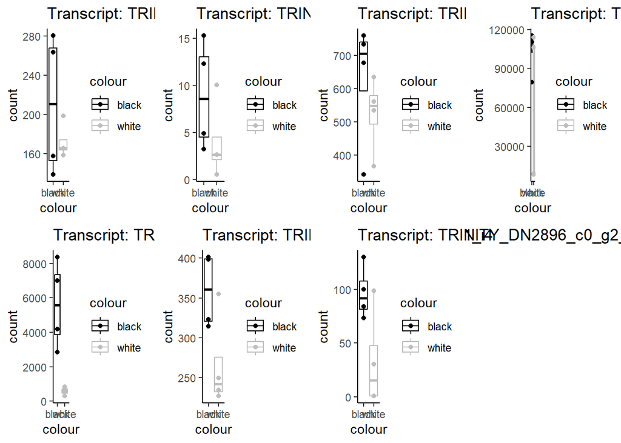

```r
melanin_annotated<-tx2gene$gene[tx2gene$transcript %in% melanin_transcripts]

plots <- list()  # To store all plots
for (tt in melanin_annotated) {
  data <- plotCounts(dds_adults, gene = tt, intgroup = c("colour"), returnData = TRUE)
  p <- ggplot(data, aes(x=colour, y=count, col=colour)) +
    geom_boxplot() +
    geom_point() +
    scale_colour_manual(values = c("black", "gray")) +
    theme_classic()+
    ggtitle(paste("Transcript:", tt))
  plots[[tt]] <- p  # Add the plot to the list
}

# Display two plots at a time in a grid
do.call(grid.arrange, c(plots, nrow = 2))
```

## 3.7 Common transcripts adults and juveniles

```r
common_transcripts<-rownames(diff_m3_res_sig005)[which(rownames(diff_m3_res_sig005) %in% rownames(res_sig005))]

tt<-tx2gene$transcript[which(tx2gene$gene==common_transcripts)]

info_common_transcripts<-GOmap[which(GOmap$gene_id %in% tt),]

#TRINITY_DN12867_c0_g1_i36=protein turtle-like isoform X1 [Argiope bruennichi]
#TRINITY_DN6814_c0_g1=metalloprotease TIKI1-like [Argiope bruennichi]
#TRINITY_DN7609_c0_g1_i3=40S ribosomal protein S17-like [Argiope bruennichi]
```

There are three common transcripts

## 3.8 Normalized counts Ommochrome associated transcripts

### 3.8.1 Juveniles

```r
ommo_transcripts<-c("TRINITY_DN18310_c0_g1_i3", "TRINITY_DN7113_c0_g1_i13", "TRINITY_DN119_c0_g1_i6", "TRINITY_DN12974_c0_g2_i1", "TRINITY_DN12012_c1_g1_i1")

ommo_ids <- tibble(
  original = ommo_transcripts,
  stripped = str_remove(ommo_transcripts, "_i\\d+$")
)

sig_ommo_juv <- tibble(
  bind_cols(as_tibble(de_juveniles)) %>%        # add DE table columns
  filter(gene_id %in% ommo_ids$original |
         gene_id %in% ommo_ids$stripped))

nrow(sig_ommo_juv)
```

```
## [1] 0
```

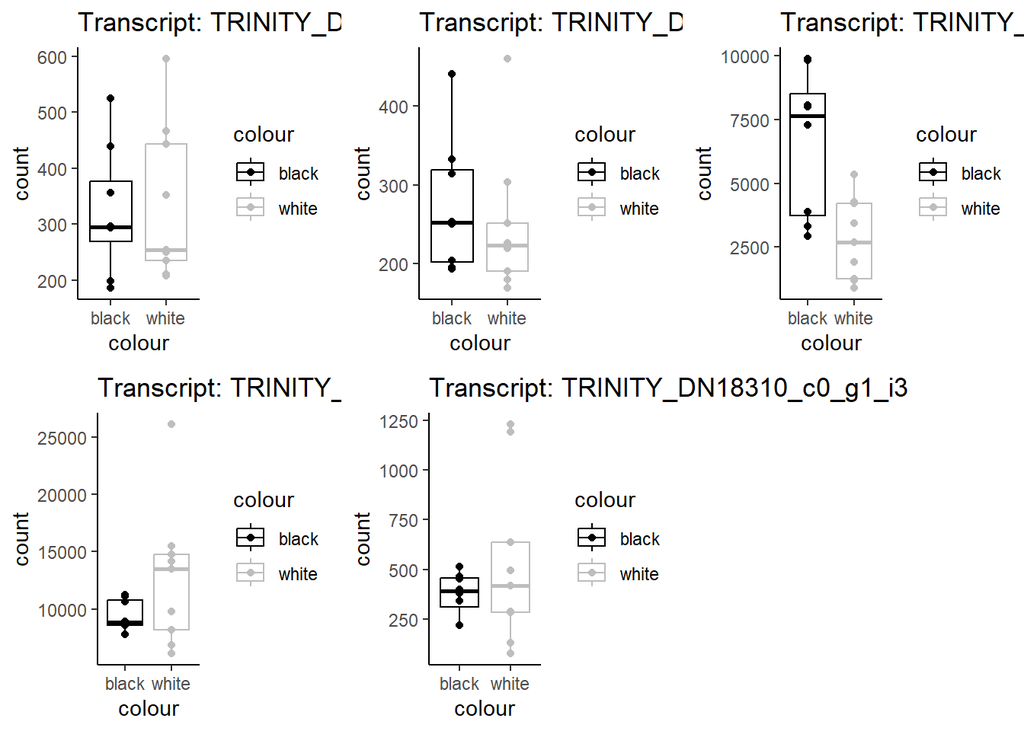

```r
ommo_annotated<-tx2gene$gene[tx2gene$transcript %in% ommo_transcripts]

plots <- list()  # To store all plots
for (tt in ommo_annotated) {
  data <- plotCounts(dds_juveniles, gene = tt, intgroup = c("colour"), returnData = TRUE)
  p <- ggplot(data, aes(x=colour, y=count, col=colour)) +
    geom_boxplot() +
    geom_point() +
    scale_colour_manual(values = c("black", "gray")) +
    theme_classic()+
    ggtitle(paste("Transcript:", tt))
  plots[[tt]] <- p  # Add the plot to the list
}

# Display two plots at a time in a grid
do.call(grid.arrange, c(plots, nrow = 2))
```

### 3.8.2 Adults

```r
ommo_transcripts<-c("TRINITY_DN18310_c0_g1_i3", "TRINITY_DN7113_c0_g1_i13", "TRINITY_DN119_c0_g1_i6", "TRINITY_DN12974_c0_g2_i1", "TRINITY_DN12012_c1_g1_i1")

ommo_ids <- tibble(
  original = ommo_transcripts,
  stripped = str_remove(ommo_transcripts, "_i\\d+$")
)

sig_ommo <- tibble(
  bind_cols(as_tibble(de_export)) %>%        # add DE table columns
  filter(gene_id %in% ommo_ids$original |
         gene_id %in% ommo_ids$stripped))

nrow(sig_ommo)
```

```
## [1] 2
```

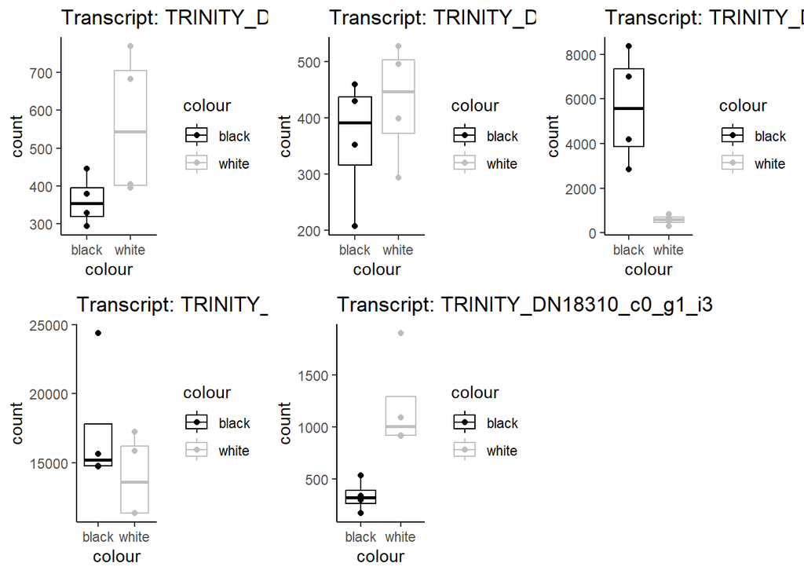

```r
ommo_annotated<-tx2gene$gene[tx2gene$transcript %in% ommo_transcripts]

plots <- list()  # To store all plots
for (tt in ommo_annotated) {
  data <- plotCounts(dds_adults, gene = tt, intgroup = c("colour"), returnData = TRUE)
  p <- ggplot(data, aes(x=colour, y=count, col=colour)) +
    geom_boxplot() +
    geom_point() +
    scale_colour_manual(values = c("black", "gray")) +
    theme_classic()+
    ggtitle(paste("Transcript:", tt))
  plots[[tt]] <- p  # Add the plot to the list
}

# Display two plots at a time in a grid
do.call(grid.arrange, c(plots, nrow = 2))
```

```r
#TRINITY_DN119_c0_g1=peroxidase-like [Argiope bruennichi]
#TRINITY_DN18310_c0_g1_i3=tryptophan 2,3-dioxygenase-like isoform X1
```

### 3.8.3 plots

export transcripts for blast

```r
#use the transcript code instead of "gene"

#adults
DE_transcripts_adults<-de_export$gene_id[which(de_export$gene_id %in% rosetta_stone$transcript)]

DE_miss_genes<-de_export$gene_id[which(!de_export$gene_id %in% rosetta_stone$transcript)]

miss_transcripts<-rosetta_stone$transcript[which(rosetta_stone$gene %in% DE_miss_genes)]

DE_transcripts_adults<-c(DE_transcripts_adults,miss_transcripts)

write_csv(tibble(transcript_id=DE_transcripts_adults),file="DE_adults.csv")

#juveniles
de_juv<-read_csv("sigDE_juveniles.txt")
DE_transcripts_juv<-de_juv$gene_id[which(de_juv$gene_id %in% rosetta_stone$transcript)]

DE_miss_genes<-de_juv$gene_id[which(!de_juv$gene_id %in% rosetta_stone$transcript)]

miss_transcripts<-rosetta_stone$transcript[which(rosetta_stone$gene %in% DE_miss_genes)]

DE_transcripts_juv<-c(DE_transcripts_juv,miss_transcripts)

write_csv(tibble(transcript_id=DE_transcripts_juv),file="DE_juv.csv")
```

Add transcripts from ommochromes and melanin with cuticle on volcano plot

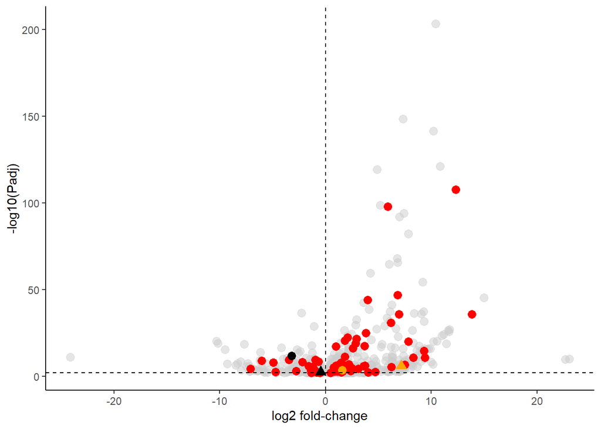

```r
## Volcano plot highlighting the transcript for easy visualization

express_values<-as_tibble(res_shrink)
express_values$gene_id<-rownames(res_shrink)
##specify colours
express_values<-express_values %>%
  mutate(colour=if_else(gene_id %in% transcript_go_melanin, "go_melanin",
                if_else(gene_id %in% melano_ids$original | gene_id %in% melano_ids$stripped, "melanin",
                if_else(gene_id %in% transcript_go_ommochrome, "go_ommo",
                if_else(gene_id %in% de_go_transcripts_unique$gene_id, "cuticle",
                if_else(gene_id %in% ommo_ids$original | gene_id %in% ommo_ids$stripped, "ommo",
                        NA_character_))))))


ggplot(data= express_values, aes(x= log2FoldChange, y= -log10(padj))) +
    #geom_point(colour= 'grey80',size=3) +
  geom_point(data=express_values[express_values$padj <= 0.01,],aes(x=log2FoldChange, y=(-log10(padj))),colour= 'grey80',size=3,alpha=0.5)+
  geom_point(data= express_values[express_values$padj <= 0.01 & express_values$colour=="cuticle",],aes(x=log2FoldChange, y=(-log10(padj))),colour= 'red',size=3, shape=19) +
    geom_point(data= express_values[express_values$padj <= 0.01 & express_values$colour=="go_melanin",],aes(x=log2FoldChange, y=(-log10(padj))),colour= 'black',size=3, shape=17) +
      geom_point(data= express_values[express_values$padj <= 0.01 & express_values$colour=="melanin",],aes(x=log2FoldChange, y=(-log10(padj))),colour= 'black',size=3, shape=19) +
      geom_point(data= express_values[express_values$padj <= 0.01 & express_values$colour=="go_ommo",],aes(x=log2FoldChange, y=(-log10(padj))),colour= 'orange',size=3, shape=17) +
      geom_point(data= express_values[express_values$padj <= 0.01 & express_values$colour=="ommo",],aes(x=log2FoldChange, y=(-log10(padj))),colour= 'orange',size=3, shape=19) +
    geom_vline(xintercept= 0, colour= 'black', linetype= 'dashed') +
    geom_hline(yintercept= 2, colour= 'black', linetype= 'dashed') +
    xlab('log2 fold-change') +
    ylab('-log10(Padj)') +
    theme_classic()
```

```r
#ommo=tryptophan 2,3-dioxygenase-like isoform X1
#go_ommo=uncharacterized protein LOC129971514 [Argiope bruennichi] | Serine/threonine-protein kinase prp4 like protein [Argiope bruennichi]
```